# hotel reservation

```python
import pandas as pd
import numpy as np
import matplotlib.pyplot as plt
import seaborn as sns
%matplotlib inline
```

```python
df=pd.read_excel(r"C:\Users\HP\Downloads\Hospitality (1).xlsx")
```

```python
df.head()
```

|  | Avg Room Rate | reservation_id | check_in_date | stay_duration | adults | children | room_type | special_requests_flag | booking_channel | reservation_status | advanced_booking | Property | Date | Rate Type |
| --- | --- | --- | --- | --- | --- | --- | --- | --- | --- | --- | --- | --- | --- | --- |
| 0 | 71.10 | 779087-Y5-9824-SA | 4/15/2020 | 13 | 3 | 4 | Single | Yes | Call Center | Completed | Yes | The Chord | 4/15/2020 | Weekday |
| 1 | 71.10 | 984023-QO-5015-YG | 2020-12-06 00:00:00 | 3 | 3 | 3 | Single | No | Travel Agent | Completed | Yes | The Chord | 2020-12-06 00:00:00 | Weekday |
| 2 | 172.38 | 518066-UQ-2315-FK | 2/25/2020 | 11 | 4 | 2 | Queen | No | Call Center | Completed | Yes | The Sankey | 2/25/2020 | Weekday |
| 3 | 172.38 | 130339-H9-2116-KE | 9/15/2020 | 11 | 4 | 1 | Queen | No | Website | No-Show | Yes | The Sankey | 9/15/2020 | Weekday |
| 4 | 199.00 | 961051-40-0956-EO | 2020-05-01 00:00:00 | 14 | 2 | 4 | Double | Yes | Walk-in | Completed | No | The Sankey | 2020-05-01 00:00:00 | Weekend |

```python
df.columns
```

```
Index(['Avg Room Rate', 'reservation_id', 'check_in_date', 'stay_duration',
       'adults', 'children', 'room_type', 'special_requests_flag',
       'booking_channel', 'reservation_status', 'advanced_booking', 'Property',
       'Date', 'Rate Type'],
      dtype='object')
```

```python
df.describe()
```

|  | Avg Room Rate | stay_duration | adults | children |
| --- | --- | --- | --- | --- |
| count | 50000.000000 | 50000.000000 | 50000.000000 | 50000.000000 |
| mean | 147.147144 | 7.473600 | 2.507560 | 2.493260 |
| std | 48.316584 | 4.050861 | 1.119164 | 1.117434 |
| min | 71.100000 | 1.000000 | 1.000000 | 1.000000 |
| 25% | 103.950000 | 4.000000 | 2.000000 | 1.000000 |
| 50% | 152.100000 | 7.000000 | 3.000000 | 2.000000 |
| 75% | 177.450000 | 11.000000 | 4.000000 | 3.000000 |
| max | 288.550000 | 14.000000 | 4.000000 | 4.000000 |

```python
df.isnull().sum()
```

```
Avg Room Rate            0
reservation_id           0
check_in_date            0
stay_duration            0
adults                   0
children                 0
room_type                0
special_requests_flag    0
booking_channel          0
reservation_status       0
advanced_booking         0
Property                 0
Date                     0
Rate Type                0
dtype: int64
```

```python
df.info()
```

```
<class 'pandas.core.frame.DataFrame'>
RangeIndex: 50000 entries, 0 to 49999
Data columns (total 14 columns):
 #   Column                 Non-Null Count  Dtype
---  ------                 --------------  -----
 0   Avg Room Rate          50000 non-null  float64
 1   reservation_id         50000 non-null  object
 2   check_in_date          50000 non-null  object
 3   stay_duration          50000 non-null  int64
 4   adults                 50000 non-null  int64
 5   children               50000 non-null  int64
 6   room_type              50000 non-null  object
 7   special_requests_flag  50000 non-null  object
 8   booking_channel        50000 non-null  object
 9   reservation_status     50000 non-null  object
 10  advanced_booking       50000 non-null  object
 11  Property               50000 non-null  object
 12  Date                   50000 non-null  object
 13  Rate Type              50000 non-null  object
dtypes: float64(1), int64(3), object(10)
memory usage: 5.3+ MB
```

# Task

Calculate and summarize the basic descriptive statistics for the ‘Avg Room Rate’ column.  Identify the maximum, minimum, mean, and median room rates.

```python
df["Avg Room Rate"].max()
```

```
288.55
```

```python
df["Avg Room Rate"].min()
```

```
71.1
```

```python
df["Avg Room Rate"].mean()
```

```
147.1471442
```

```python
df["Avg Room Rate"].median()
```

```
152.1
```

```python
df["Avg Room Rate"].describe()
```

```
count    50000.000000
mean       147.147144
std         48.316584
min         71.100000
25%        103.950000
50%        152.100000
75%        177.450000
max        288.550000
Name: Avg Room Rate, dtype: float64
```

```python
df.room_type.value_counts()
```

```
Double             12936
Single             10764
Queen               8872
Suite               6623
King                6565
Executive Suite     4240
Name: room_type, dtype: int64
```

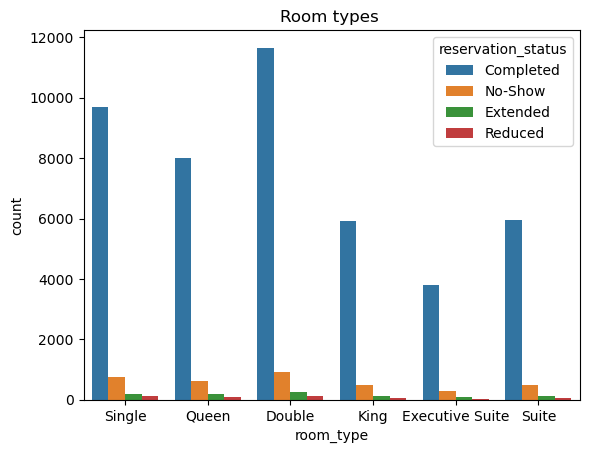

```python
sns.countplot(x="room_type",y=None,hue="reservation_status",data=df)
plt.title("Room types ")
```

Room Type Analysis:  Analyze the distribution of room types (‘Room Type’ column).  Determine the most and least popular room types based on the number of reservations.

```python
df["booking_channel"].value_counts()
```

```
Phone App       15391
Travel Agent    11574
Website         11532
Call Center      7700
Walk-in          3803
Name: booking_channel, dtype: int64
```

```python
b=df[df["reservation_status"]=="Completed"].groupby("booking_channel").size().reset_index().rename(columns={0:"booking"})
```

```python
print(b)
```

```
  booking_channel  booking
0     Call Center     6920
1       Phone App    13848
2    Travel Agent    10488
3         Walk-in     3400
4         Website    10379
```

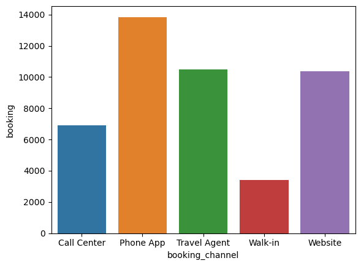

```python
sns.barplot(x="booking_channel",y="booking",data=b)
```

Booking Channel Insights:  Investigate the distribution of booking channels (‘Booking Channel’ column).  Identify the most effective booking channel based on the number of completed reservations.

```python
reservation=df.reservation_status.value_counts()
names=df["reservation_status"].value_counts().index
```

```python
reservation
```

```
Completed    45035
No-Show       3550
Extended       953
Reduced        462
Name: reservation_status, dtype: int64
```

[output not shown]

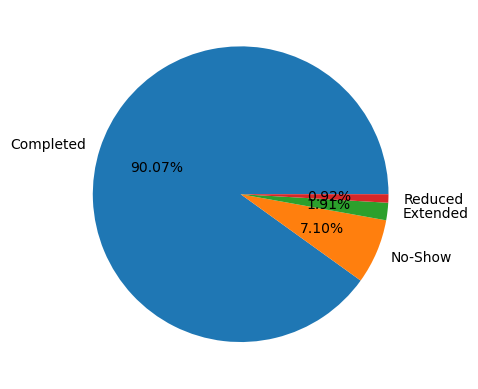

```python
plt.pie(reservation,labels=names,autopct="%1.2f%%")
```

Reservation Status Analysis:  Explore the distribution of reservation statuses (‘Reservation Status’ column).  Calculate the percentage of completed, no-show, and other reservaƟon statuses.

```python
df[df["Rate Type"]=="Weekday"].groupby("Rate Type")["Avg Room Rate"].mean()
```

```
Rate Type
Weekday    142.031001
Name: Avg Room Rate, dtype: float64
```

```python
df[df["Rate Type"]=="Weekend"].groupby("Rate Type")["Avg Room Rate"].mean()
```

```
Rate Type
Weekend    159.810204
Name: Avg Room Rate, dtype: float64
```

```python
df.Property.value_counts()
```

```
The Sankey       27400
The Marimekko    13666
The Chord         8934
Name: Property, dtype: int64
```

```python
df["Avg Room Rate"].mean()
```

```
147.1471442
```

# Analyze the performance of different properties (‘Property’ column).

 Identify the property with the highest average room rate and the one with the most reservations.

```python
df[df["Property"]=="The Chord"].groupby("Property")["Avg Room Rate"].mean()
```

```
Property
The Chord    88.133999
Name: Avg Room Rate, dtype: float64
```

```python
df[df["Property"]=="The Marimekko"].groupby("Property")["Avg Room Rate"].mean()
```

```
Property
The Marimekko    110.153924
Name: Avg Room Rate, dtype: float64
```

```python
df[df["Property"]=="The Sankey"].groupby("Property")["Avg Room Rate"].mean()
```

```
Property
The Sankey    184.839581
Name: Avg Room Rate, dtype: float64
```

observation= The SAnkey has the highest average room rate

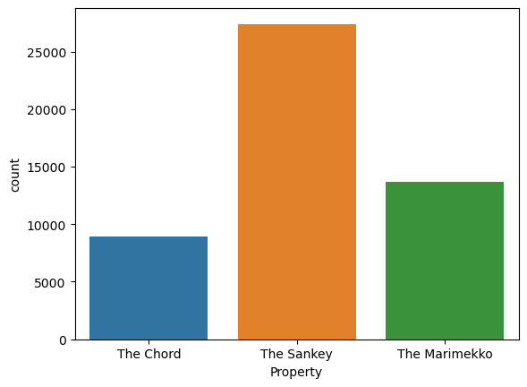

```python
sns.countplot(x="Property",y=None,data=df)
```

# Investigate the impact of advanced booking (‘Advanced Booking’ column) on

reservation completion.  Compare the completion rates for advanced bookings and regular bookings.

```python
advance_booking=df[df["reservation_status"]=="Completed"].groupby("advanced_booking").size().reset_index()
```

observation= advance booking is greater than regular booking

```python
advance_booking
```

|  | advanced_booking | 0 |
| --- | --- | --- |
| 0 | No | 7090 |
| 1 | Yes | 37945 |

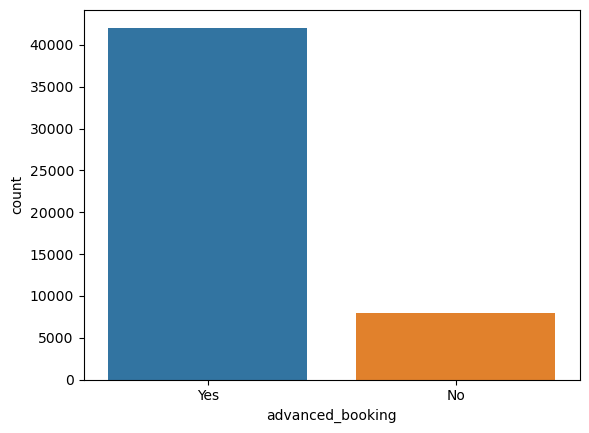

```python
sns.countplot(x="advanced_booking",y=None,data=df)
```